# homework2

Ali Seyit Zararsız

07 05 2021

# Introduction

The aim of this study is to forecast the total number of first hand housing sales in Turkey at April 2021 with creating models. Many people tend to spend their money on houses since it feels like a big step in our society. Therefore, it is one of the major indicators in macroeconomics. With the time series data, it enables us to forecast future values.

All the datas are taken from EVDS and chosen independent factors are: 1. Survey about plans to buy a home 2. Interest rates of housing loans.

# Data Manipulations

Libraries used for this project:

```r
knitr::opts_chunk$set(echo = FALSE)
setwd("C:\\Users\\aliseyit\\Documents\\GitHub\\spring21-aliseyitzararsiz\\files\\homework2")

library(ggplot2)
library(zoo)
library(openxlsx)
library(data.table)
library(forecast)
library(GGally)
data <- read.xlsx("Turkey_first_hand_sale.xlsx",colNames = TRUE)
data$Date <- as.yearmon(data$Date)
sales<-as.data.table(data)
tail(data)
```

```
##        Date Sales Interest_rates Survey
## 94 Eki 2020 36976          15.07   8.40
## 95 Kas 2020 36658          15.68   8.81
## 96 Ara 2020 36898          18.19   8.84
## 97 Oca 2021 22268          18.39  10.67
## 98 Şub 2021 24737          17.99  10.35
## 99 Mar 2021 33365          17.74  10.45
```

```r
data_timeseries <- ts(data,frequency=12, start=c(2013,1))
```

# Analysis

We need to visualize the target variable to see if there is any pattern on the time series data.

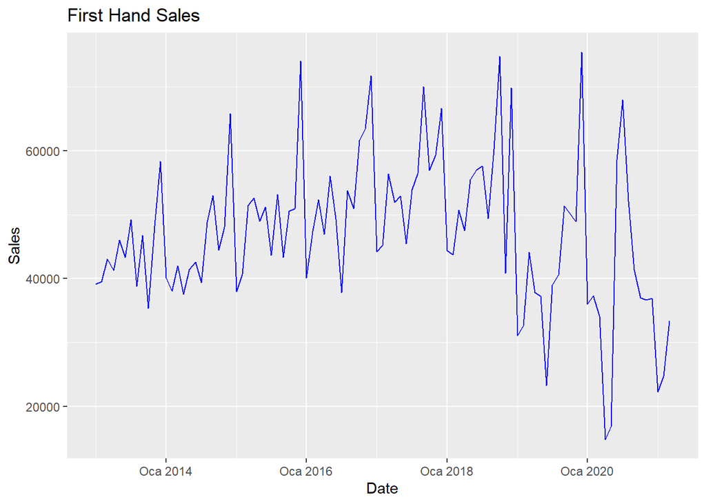

```r
ggplot(data, aes(x=Date, y=Sales)) + geom_line(color="blue")+ ggtitle("First Hand Sales") + xlab("Date") + ylab("Sales")
```

We can see that there is an increasing trend and some seasonality until 2019. After that point variance has increased and trend slope changed its direction.

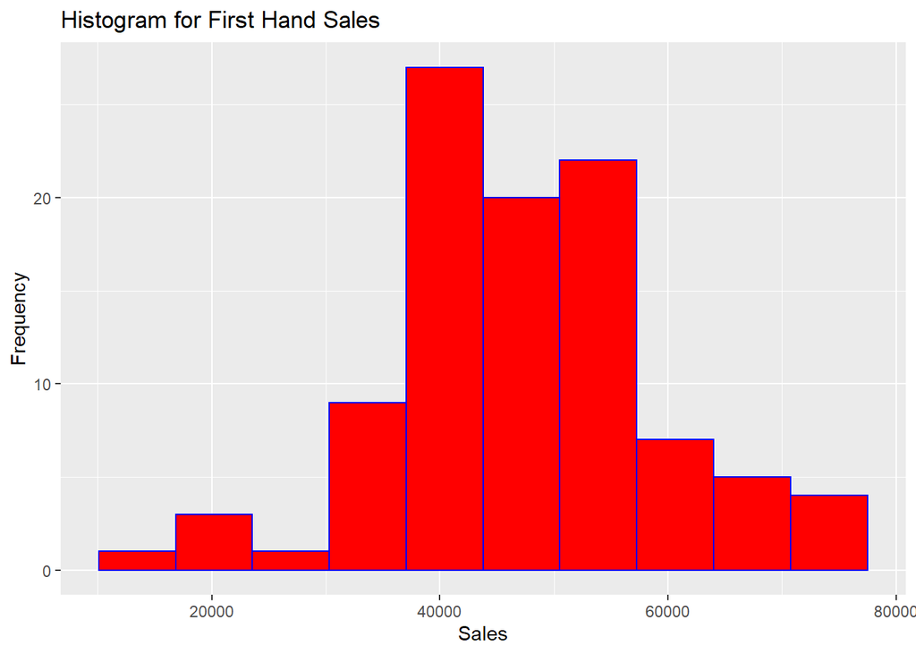

```r
ggplot(data, aes(Sales))+geom_histogram(bins=10,color="blue",fill="red")+ggtitle("Histogram for First Hand Sales") + xlab("Sales") + ylab("Frequency")
```

By looking at this histogram, we can see that this data distributes normally with some outliers and high variances.

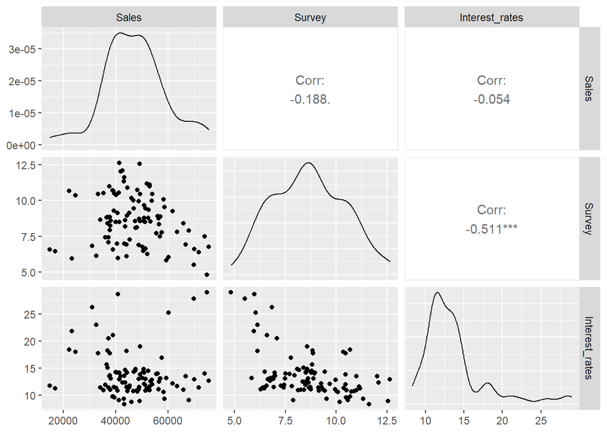

Here you can see,our data has not significant correlations. That’s why our model probably will not work as expected. Survey can be chosen as a regressor for the model.

# Model

We are starting to build our model. Trend component is searched.

```
##
## Call:
## lm(formula = Sales ~ trend, data = sales)
##
## Residuals:
##      Min       1Q   Median       3Q      Max
## -30755.8  -8347.5   -728.6   6103.4  29706.8
##
## Coefficients:
##             Estimate Std. Error t value Pr(>|t|)
## (Intercept) 49330.60    2395.58  20.592   <2e-16 ***
## trend         -42.35      41.60  -1.018    0.311
## ---
## Signif. codes:  0 '***' 0.001 '**' 0.01 '*' 0.05 '.' 0.1 ' ' 1
##
## Residual standard error: 11830 on 97 degrees of freedom
## Multiple R-squared:  0.01057,    Adjusted R-squared:  0.0003727
## F-statistic: 1.037 on 1 and 97 DF,  p-value: 0.3112
```

High p-value and the low r-squared value shows us that this model is not significant.

It is time to check if there is any seasonality component.

```
##
## Call:
## lm(formula = Sales ~ trend + as.factor(month), data = sales)
##
## Residuals:
##      Min       1Q   Median       3Q      Max
## -25620.7  -5421.6    400.7   6411.3  24435.7
##
## Coefficients:
##                    Estimate Std. Error t value Pr(>|t|)
## (Intercept)        39991.77    3763.71  10.626  < 2e-16 ***
## trend                -55.80      35.36  -1.578  0.11826
## as.factor(month)2   1607.13    4725.24   0.340  0.73460
## as.factor(month)3   8141.59    4725.64   1.723  0.08851 .
## as.factor(month)4   3880.83    4871.69   0.797  0.42787
## as.factor(month)5   7022.26    4871.05   1.442  0.15304
## as.factor(month)6   9050.80    4870.66   1.858  0.06656 .
## as.factor(month)7  11302.60    4870.53   2.321  0.02268 *
## as.factor(month)8  11956.02    4870.66   2.455  0.01612 *
## as.factor(month)9  14994.94    4871.05   3.078  0.00279 **
## as.factor(month)10 14293.23    4871.69   2.934  0.00429 **
## as.factor(month)11 12536.41    4872.59   2.573  0.01180 *
## as.factor(month)12 27883.33    4873.74   5.721 1.51e-07 ***
## ---
## Signif. codes:  0 '***' 0.001 '**' 0.01 '*' 0.05 '.' 0.1 ' ' 1
##
## Residual standard error: 10020 on 86 degrees of freedom
## Multiple R-squared:   0.37,  Adjusted R-squared:  0.2821
## F-statistic: 4.209 on 12 and 86 DF,  p-value: 3.428e-05
```

This a better model than the first one since its p value is smaller and adjusted r-squared value is higher.

Survey regressor is added to the model.

```
##
## Call:
## lm(formula = Sales ~ Survey + trend + as.factor(month), data = sales)
##
## Residuals:
##      Min       1Q   Median       3Q      Max
## -27003.9  -5518.4    409.7   5724.0  22341.6
##
## Coefficients:
##                    Estimate Std. Error t value Pr(>|t|)
## (Intercept)        55412.33    8594.48   6.447 6.60e-09 ***
## Survey             -1483.84     746.41  -1.988  0.05003 .
## trend               -105.97      42.96  -2.466  0.01565 *
## as.factor(month)2   1556.73    4646.24   0.335  0.73841
## as.factor(month)3   9150.37    4674.19   1.958  0.05355 .
## as.factor(month)4   4686.57    4807.28   0.975  0.33238
## as.factor(month)5   7468.25    4794.79   1.558  0.12305
## as.factor(month)6   9819.63    4804.75   2.044  0.04408 *
## as.factor(month)7  11533.62    4790.44   2.408  0.01822 *
## as.factor(month)8  11895.93    4789.25   2.484  0.01496 *
## as.factor(month)9  14282.06    4802.94   2.974  0.00383 **
## as.factor(month)10 13467.30    4808.15   2.801  0.00631 **
## as.factor(month)11 11456.46    4821.75   2.376  0.01975 *
## as.factor(month)12 26382.43    4851.29   5.438 5.08e-07 ***
## ---
## Signif. codes:  0 '***' 0.001 '**' 0.01 '*' 0.05 '.' 0.1 ' ' 1
##
## Residual standard error: 9856 on 85 degrees of freedom
## Multiple R-squared:  0.398,  Adjusted R-squared:  0.3059
## F-statistic: 4.322 on 13 and 85 DF,  p-value: 1.556e-05
```

Our model is getting better however still not enough.

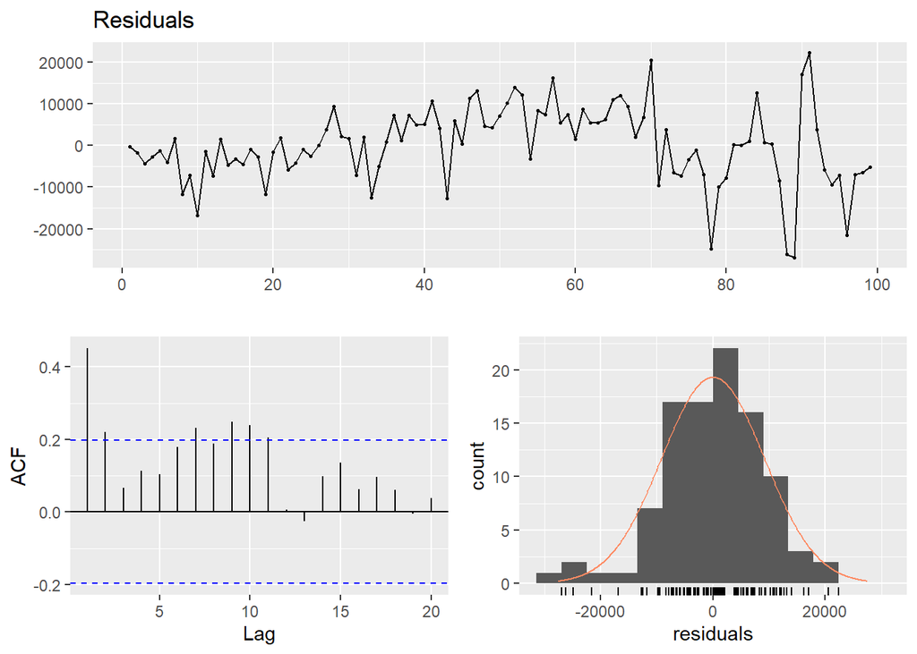

```
##
##  Breusch-Godfrey test for serial correlation of order up to 17
##
## data:  Residuals
## LM test = 42.584, df = 17, p-value = 0.000552
```

Here the normal distribution fits better than other models. Now it is time to plot our model to see its validation.

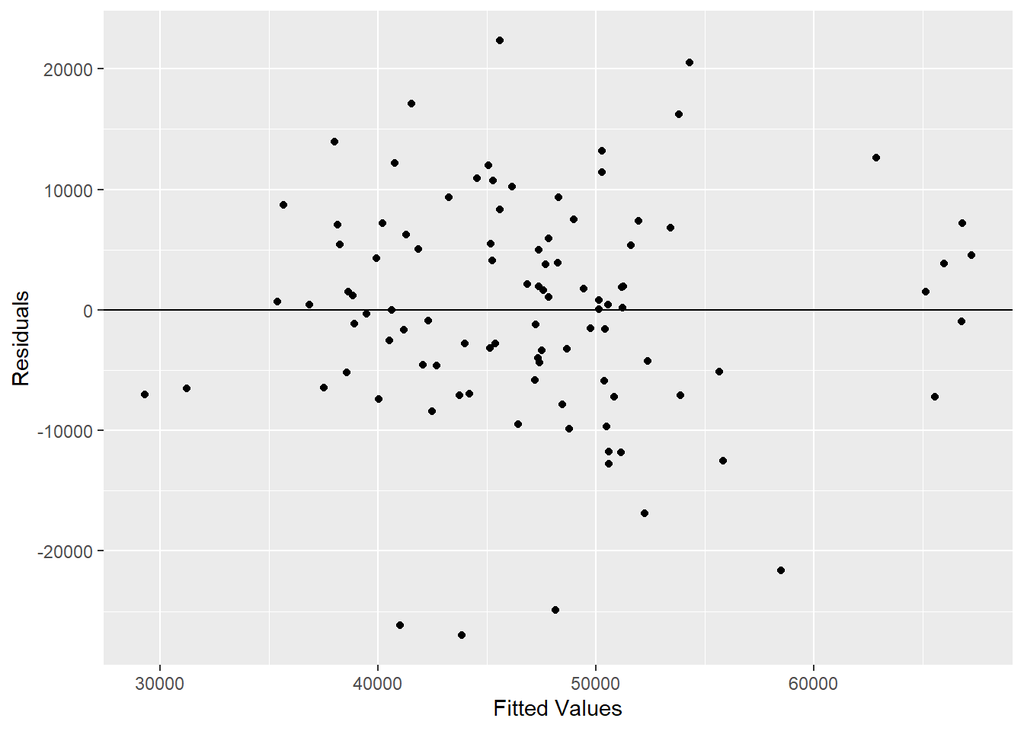

Resiudals are randomly distributed can be said however positive and outlier points still stands.

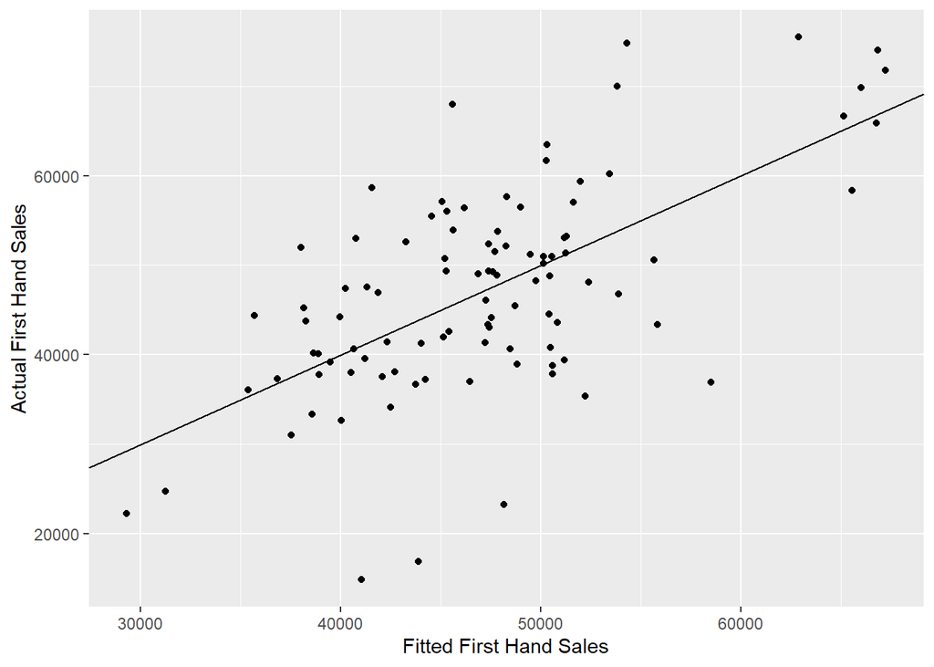

Fitted and actual values does not fit highly however, it is still useful to predict our target variable.

# Forecasting

```
##     Point Forecast    Lo 80    Hi 80    Lo 95    Hi 95
## 100       10.08774 8.501450 11.67402 7.661721 12.51375
## 101       10.08774 8.367560 11.80791 7.456954 12.71852
## 102       10.08774 8.243364 11.93211 7.267013 12.90846
## 103       10.08774 8.127020 12.04845 7.089079 13.08639
## 104       10.08774 8.017202 12.15827 6.921128 13.25434
## 105       10.08774 7.912923 12.26255 6.761647 13.41383
## 106       10.08774 7.813420 12.36205 6.609470 13.56600
## 107       10.08774 7.718092 12.45738 6.463678 13.71179
## 108       10.08774 7.626453 12.54902 6.323528 13.85194
## 109       10.08774 7.538105 12.63737 6.188412 13.98706
```

```
##     Point Forecast    Lo 80    Hi 80    Lo 95    Hi 95
## 100        36305.6 21916.75 50694.46 14299.75 58311.46
## 101        36305.6 21765.81 50845.40 14068.91 58542.30
## 102        36305.6 21616.42 50994.79 13840.43 58770.77
## 103        36305.6 21468.53 51142.68 13614.26 58996.95
## 104        36305.6 21322.10 51289.10 13390.32 59220.89
## 105        36305.6 21177.09 51434.11 13168.54 59442.66
## 106        36305.6 21033.46 51577.75 12948.88 59662.33
## 107        36305.6 20891.17 51720.04 12731.26 59879.95
## 108        36305.6 20750.17 51861.03 12515.63 60095.58
## 109        36305.6 20610.45 52000.76 12301.93 60309.27
```

Here we can find the point forecasted value of 36305.6 for April 2021.

# Conclusion

Our model does not fit very well since its correlation values with regressors are not significant. For that reason I expect that the forecasted value of this model will not fit with the actual value of April 2021. The April value has still not announced yet, therefore I could not check this model is validated or not. However my prediction of the residual value will be very large.